# MIDI-MT - Launching the application

MIDI-MT Documentation in English

## First start

After starting the application, you need to launch **the MIDI translator** itself. Find the **MIDI-MT** application icon in the tray, open the menu and select “ **Start**”. A dialog will open in which you can change the basic settings and start the translator.

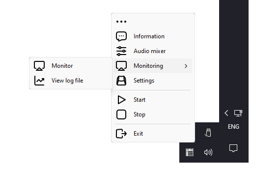

### MIDI port naming convention

- You can select the MIDI input port from the list; this can be done by selecting the “interaction with MIDI devices” module control.
- Automatically created MIDI output ports on which **MIDI-Mackie** notations are generated have a name made up of the serial number of the input port and the prefix **MIDI-MT-Mackie-Out-(number)**.
- The MIDI proxy port name is formed in a similar way; the prefix for it will be **MIDI-MT-Proxy-Out-(number)**.

  For example:

```yaml
Input MIDI port:  W-FADER                // MIDI Controller
Output MIDI port: MIDI-MT-Mackie-Out-1   // Premiere Pro (MIDI Mackie) port
Proxy MIDI port:  MIDI-MT-Proxy-Out-1    // to connect any application
                                         // for parallel control from the controller
```

The exact names of the ports can be obtained using the menu item “**Monitoring**” > “**View log file**” > “**Plugins**” > “**Plugin statistics**”, when **MIDI-MT** is running.

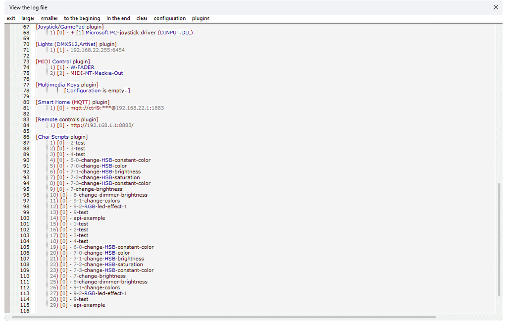

MIDI-MT plugin statistics

### Behavior

- The “**auto start**” item is checked, the dialog will not wait for the “**Start**” button to be pressed, but will launch the translator the moment it opens.
- If the “**start on boot**” item is checked, **the MIDI-MT** application will be loaded when the application automatically starts when the operating system boots. If the “**auto start**” item is active, the translator will start automatically.
- The “**record log**” item is responsible for recording occurring events to a file for possible further analysis of failure/disconnection/connection of MIDI equipment.
- You can read more about the application’s controls and behavior on the Settings and Configuration Files pages.

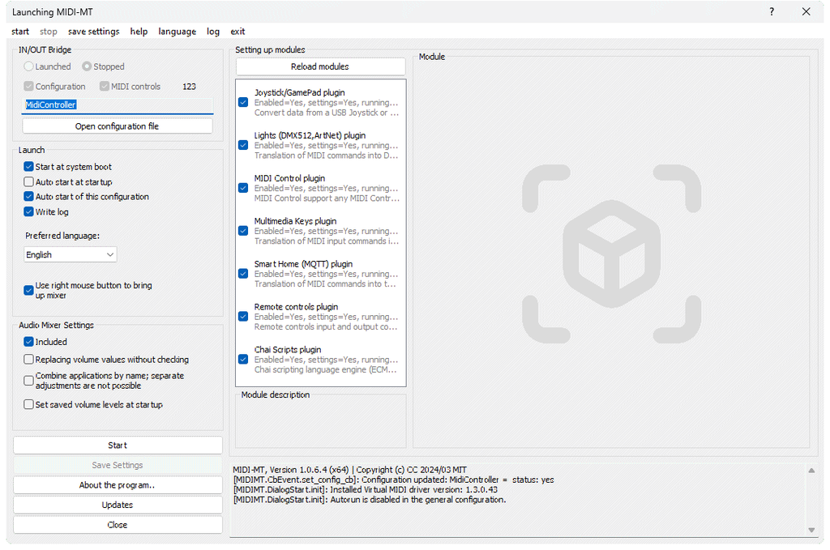

### Operations

If the “**auto start**” item **is not** activated, to start the translator, you must press the “**Start**” button in the main menu. The changes made can be saved in the configuration file using the “**Save settings**” button. In the future, these settings will be applied automatically. To exit the “**Start**” dialog, as well as other dialogs, click the “**Close**” button. The “**About**” and “**Updates**” buttons are intuitive and self-explanatory.

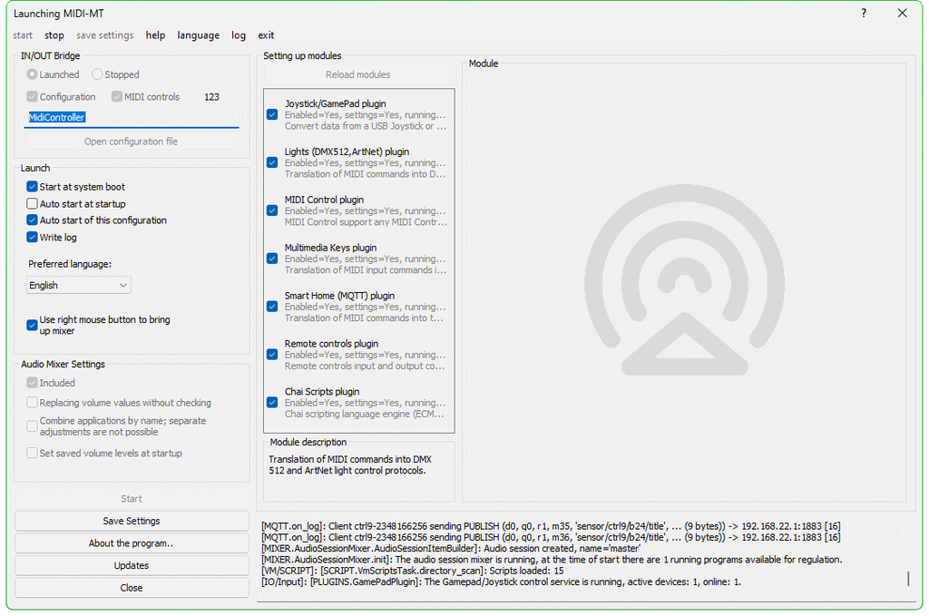

When starting, it is possible to use command line switches. The syntax of the switches is described in detail in the section - Command Line Options.